# Behzat Ç - Group Project

Group Members:

- [Atahan Şenşatar](https://pjournal.github.io/mef03-atahan01/)
- [Batuhan Arslan](https://pjournal.github.io/mef03-arslnbatu/)
- [M.Cem Özçilingir](https://pjournal.github.io/mef03-mclngr/)
- [Tibet Erdoğan](https://pjournal.github.io/mef03-tibeterdogan/)
- [Nilay Kamar](https://pjournal.github.io/mef03-kamarn/)

```r
options(sqldf.driver = "SQLite")
```

# 1 Key takeaways

We analyzed change of baby names in USA over the years. In this project, we examined that:

# 2 Objectives:

- Get raw data and arrange according to the result we want to learn
- After put in order data visualize it and make INFERENCES
- Finding more efficient reason with various data.
- Using all dataset to find optimal solution.

# 3 Overview and Preliminary

```r
knitr::opts_chunk$set(echo = TRUE)
knitr::opts_knit$set(root.dir = normalizePath(".."))

StateNames <- read.csv("/Users/nilaykamar/Desktop/BDM/behzat_c/StateNames.csv")
NationalNames <- read.csv("/Users/nilaykamar/Desktop/BDM/behzat_c/NationalNames.csv")
```

```r
NationalNames$Gender <- as.character(NationalNames$Gender)
NationalNames$Name <- as.character(NationalNames$Name)
StateNames$Gender <- as.character(StateNames$Gender)
StateNames$Name <- as.character(StateNames$Name)

NationalNames$Gender = str_replace(NationalNames$Gender, 'M', 'Male')
NationalNames$Gender = str_replace(NationalNames$Gender, 'F', 'Female')
StateNames$Gender = str_replace(StateNames$Gender, 'M', 'Male')
StateNames$Gender = str_replace(StateNames$Gender, 'F', 'Female')
```

There are two dataframe which we used in this project, and their columns are:

StateNames:

- id
- name
- year
- gender
- state
- count

NationalNames:

- id
- name
- year
- gender
- count

```r
head(NationalNames)
```

```
  Id      Name Year Gender Count
1  1      Mary 1880 Female  7065
2  2      Anna 1880 Female  2604
3  3      Emma 1880 Female  2003
4  4 Elizabeth 1880 Female  1939
5  5    Minnie 1880 Female  1746
6  6  Margaret 1880 Female  1578
```

```r
head(StateNames)
```

```
  Id     Name Year Gender State Count
1  1     Mary 1910 Female    AK    14
2  2    Annie 1910 Female    AK    12
3  3     Anna 1910 Female    AK    10
4  4 Margaret 1910 Female    AK     8
5  5    Helen 1910 Female    AK     7
6  6    Elsie 1910 Female    AK     6
```

# 4 Analysis

```r
unique_names <- sqldf('SELECT Year, Gender, sum(Count)
                      FROM NationalNames
                      GROUP BY Year, Gender')
```

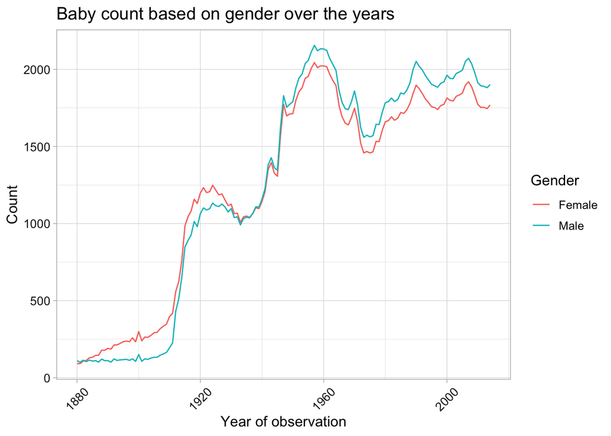

```r
ggplot(unique_names) +
  geom_line(aes(Year, y = unique_names$`sum(Count)`/1000, color = Gender)) +
  labs(title = "Baby count based on gender over the years",
       x = "Year of observation",
       y = "Count")+
  theme_light() +
  theme(axis.text.x = element_text(colour = "grey10", size = 10, angle = 45, hjust = 0.5, vjust = 0.5),
        axis.text.y = element_text(colour = "grey10", size = 10),
        text = element_text(size = 12))
```

## 4.2 Most Popular Names in States

```r
knitr::opts_chunk$set(echo = TRUE)
knitr::opts_knit$set(root.dir = "/Users/nilaykamar/Desktop/BDM/behzat_c")

query <- sqldf('SELECT State, Name, max(Count) Count, Year
               FROM StateNames
               GROUP BY State
               ORDER BY Year')
query
```

```
   State     Name Count Year
1     PA     Mary  8184 1918
2     AL    James  3038 1947
3     AR    James  1620 1947
4     CT   Robert  1622 1947
5     DC     John   884 1947
6     GA    James  3066 1947
7     IA    Linda  2365 1947
8     ID    Linda   530 1947
9     IN    Linda  3012 1947
10    KS    Linda  1387 1947
11    KY    James  2553 1947
12    MA   Robert  3895 1947
13    ME    Linda   778 1947
14    MO    Linda  2797 1947
```

[output cut: 37 more lines]

Results show that most of the maximum counts are between 1947 and 1958. This rise can be arise from baby boomer generation.

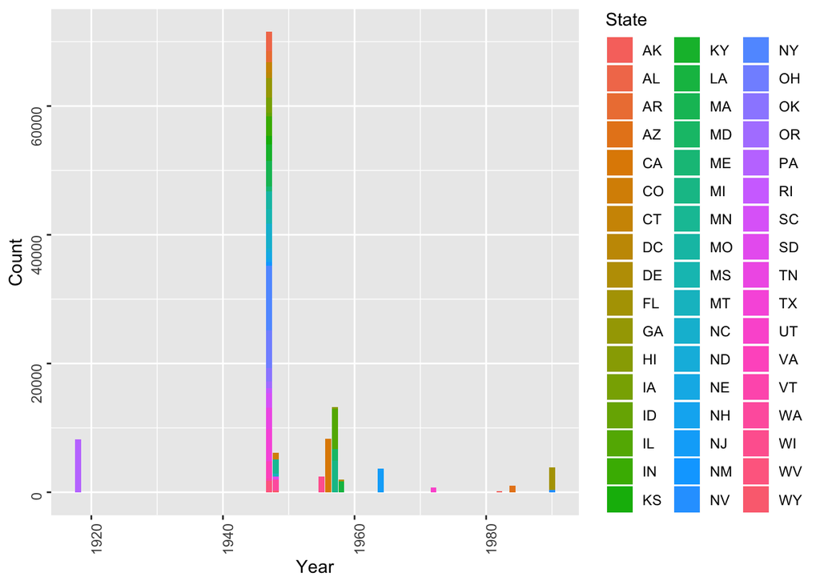

```r
knitr::opts_chunk$set(echo = TRUE)
knitr::opts_knit$set(root.dir = "/Users/nilaykamar")

ggplot(data = query, aes(x = Year, y = Count, fill = State)) +
  geom_bar(stat = "identity") + theme(axis.text = element_text(angle = 90))
```

## 4.3 Traditional Names vs. Modern Names

```r
knitr::opts_chunk$set(echo = TRUE)
knitr::opts_knit$set(root.dir = "/Users/nilaykamar/Desktop/BDM/behzat_c")

library(sqldf)
Popular_names <- sqldf('select Name, sum(Count) as Count
                From NationalNames
                group by Name
                order by Count desc
                LIMIT 10000')

Traditionalnames <- sqldf('Select Name, sum(Count) as Count
                                    From NationalNames
                                    group by Name
                                    having max(Year) < 1990
                                    ORDER BY Count desc')

Modernames <- sqldf('Select Name, sum(Count) as Count
                                    From NationalNames
                                    group by Name
                                    having min(Year) > 1990
                    ORDER BY Count desc')
```

```r
head(Traditionalnames)
```

```
     Name Count
1 Flossie 21829
2     Gay 19366
3  Bertie 14491
4   Madge 13425
5    Floy  6934
6  Dortha  6811
```

```r
head(Modernames)
```

```
    Name Count
1 Nevaeh 65093
2 Jaylen 33499
3 Jaiden 31438
4 Kaiden 26857
5 Jaxson 26158
6 Maddox 21954
```

```r
knitr::opts_chunk$set(echo = TRUE)
knitr::opts_knit$set(root.dir = "/Users/nilaykamar/Desktop/BDM/behzat_c")

inner_join(Traditionalnames, Popular_names, by = "Name")
```

```
           Name Count.x Count.y
1       Flossie   21829   21829
2           Gay   19366   19366
3        Bertie   14491   14491
4         Madge   13425   13425
5          Floy    6934    6934
6        Dortha    6811    6811
7        Blanch    6450    6450
8      Hortense    6312    6312
9        Mittie    6297    6297
10        Verla    6190    6190
11       Myrtis    6125    6125
12         Gaye    5747    5747
13       Ardith    5712    5712
14        Syble    5535    5535
```

[output cut: 318 more lines]

```r
inner_join(Modernames, Popular_names, by = "Name")
```

```
          Name Count.x Count.y
1       Nevaeh   65093   65093
2       Jaylen   33499   33499
3       Jaiden   31438   31438
4       Kaiden   26857   26857
5       Jaxson   26158   26158
6       Maddox   21954   21954
7       Aniyah   20318   20318
8      Maximus   17666   17666
9     Kaydence   12639   12639
10      Zayden   10415   10415
11     Kadence    9370    9370
12       Yahir    9202    9202
13     Janiyah    9039    9039
14         Jax    8965    8965
```

[output cut: 392 more lines]

## 4.4 Most used names in states

This list shown us which names are most used in states, and which are the toppest in more than one states. Olivia seems to the most popular name in 2014.

```r
knitr::opts_chunk$set(echo = TRUE)
knitr::opts_knit$set(root.dir = "/Users/nilaykamar/Desktop/BDM/behzat_c")

sqldf("SELECT name,count(name)
                   from (Select name, year, MAX(count), State
                         FROM StateNames
                         Where year=2014 Group by State ) as maxi
                   group by name
                   having count(name) > 2
                   order by count(name) desc")
```

```
     name count(name)
1  Olivia          11
2 William           9
3    Emma           9
4    Liam           6
5  Sophia           3
6   Mason           3
```

## 4.5 Gender Neutral Names based on state

```r
knitr::opts_chunk$set(echo = TRUE)
knitr::opts_knit$set(root.dir = "/Users/nilaykamar/Desktop/BDM/behzat_c")

Genderneutral <- sqldf('Select distinct(a.Name)
                        From (
                                Select Name
                                From NationalNames
                                Where Gender = "Male") as a INNER JOIN (
                                Select Name
                                From NationalNames
                                Where Gender = "Female") as b on a.Name = b.Name')
```

```r
state_neutral <- sqldf('SELECT a.State, sum(a.Count) as Total
                       FROM StateNames as a, (Select distinct(a.Name)
                        From (
                                Select Name
                                From NationalNames
                                Where Gender = "Male") as a INNER JOIN (
                                Select Name
                                From NationalNames
                                Where Gender = "Female") as b on a.Name = b.Name) as b
                                WHERE b.Name = a.Name
                       GROUP BY a.State')
```

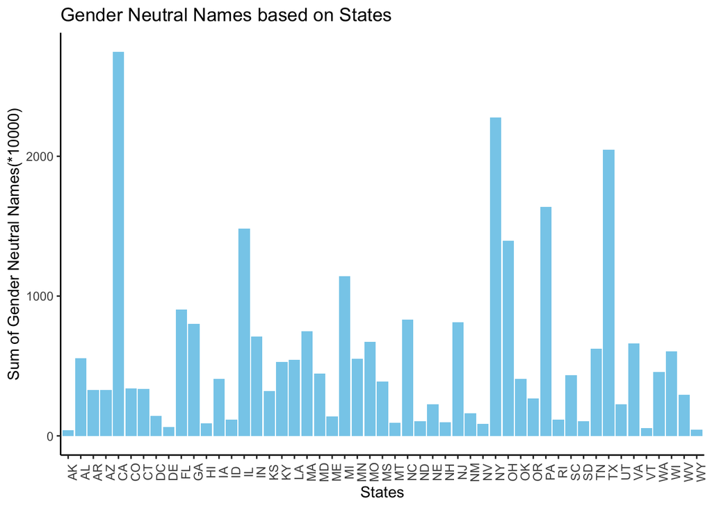

```r
ggplot(state_neutral) +
  geom_bar(aes(State, Total/10000), stat = "identity", fill = "sky blue") +
  theme_classic() +
  labs(x="States", y="Sum of Gender Neutral Names(*10000)", title="Gender Neutral Names based on States") +
  theme(axis.text.x = element_text(angle=90))
```

```r
Traditionalnames <- sqldf('Select Name, sum(Count)
                                    From NationalNames
                                    group by Name
                                    having max(Year) < 1990')
```